# Tabla de Productos y Precios

## Santiago Diez Juan Rivero Agustín Rodriguez Tomás Boismene Lucas Patiri

### Estamos creando una empresa donde necesitamos 4 computadoras con distintos costos, hacemos una grafica y una tabla que los muestre

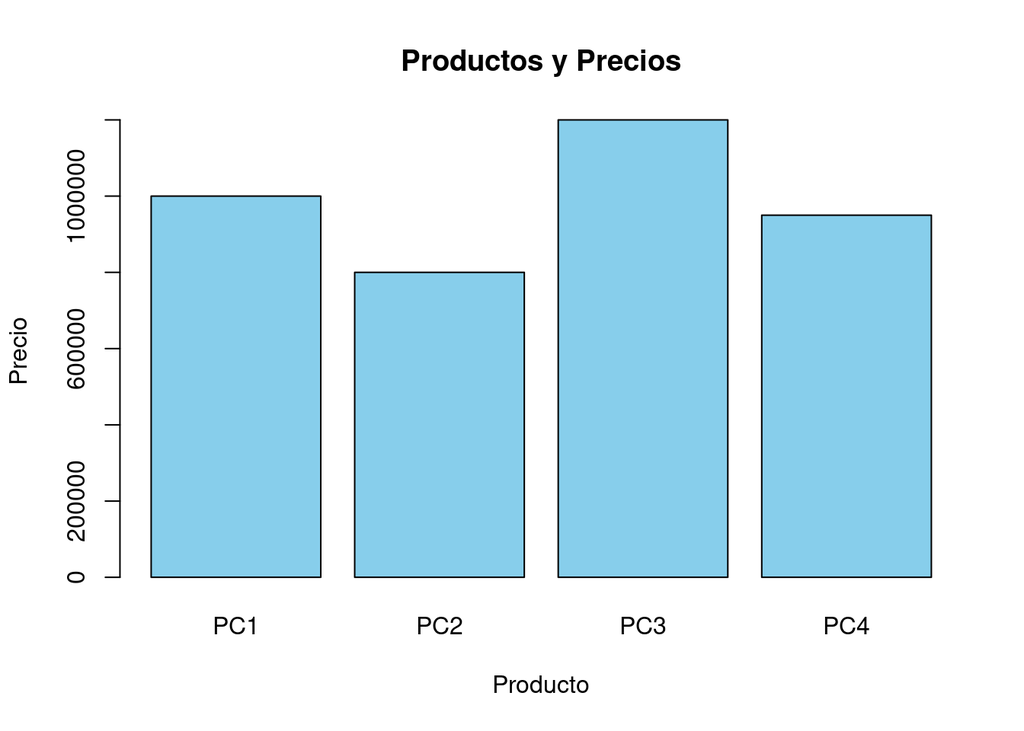

| Producto | Precio |
| --- | --- |
| PC1 | 1000000 |
| PC2 | 800000 |
| PC3 | 1200000 |
| PC4 | 950000 |

## Tutorial básico de R

1. Asignación de variables Puedes asignar valores a variables utilizando el operador <- o = x <- 5 y = 10
2. Operaciones aritméticas suma <- 3 + 4 resta <- 7 - 2 multiplicacion <- 5 * 2 division <- 10 / 2 potenciacion <- 2^3
3. Vectores Los vectores son una colección ordenada de elementos del mismo tipo. vector_numerico <- c(1, 2, 3, 4, 5) vector_caracter <- c(“a”, “b”, “c”, “d”, “e”)
4. Funciones R tiene muchas funciones integradas que puedes usar para realizar tareas específicas. Por ejemplo, la función mean() calcula la media de un conjunto de números. numeros <- c(1, 2, 3, 4, 5) media <- mean(numeros)
5. Data frames Los data frames son estructuras de datos bidimensionales que se usan para almacenar conjuntos de datos. Puedes crear data frames utilizando la función data.frame(). edades <- c(25, 30, 35) nombres <- c(“Juan”, “María”, “Pedro”) df <- data.frame(Edad = edades, Nombre = nombres)
6. Indexación de vectores y data frames Puedes acceder a elementos individuales de un vector o data frame utilizando corchetes []. primer_elemento <- vector_numerico[1] nombre_primera_fila <- df[1, “Nombre”]
7. Gráficos R es conocido por su capacidad para generar gráficos de alta calidad. Puedes crear gráficos utilizando funciones como plot(), hist(), barplot(), entre otras.